# CI coverage simulation

Dr. Matthew Beckman

# Simulation

#### Result from a real study about carbon capture in tropical forests:

> 95% CI: 11,600 ± 2⋅1000 = (9,600, 13,600)

> “We are 95% confident that the average amount of carbon stored in each square kilometer of tropical forest is between 9,600 and 13,600 tons”

What’s wrong with saying “there’s a 95% chance that the average amount of carbon stored in each square kilometer of tropical forest is between 9,600 and 13,600 tons” ??

```r
normDatSim <- rnorm(n = 15, mean = 11600, sd = 1000)

# ggplot() +
#   geom_density(aes(normDatSim))

t.test(normDatSim)
```

```
    One Sample t-test

data:  normDatSim
t = 39.396, df = 14, p-value = 9.597e-16
alternative hypothesis: true mean is not equal to 0
95 percent confidence interval:
 10831.15 12078.39
sample estimates:
mean of x
 11454.77
```

# Simulation with Loops

```r
# simulation settings

nsimulations <- 100
mu <- 11600
sigma <- 1000
sampleSize <- 15

# initialize a data frame where we can store various results at each step in our simulation

ConfIntDat <- data.frame(simulationID = rep(NA, nsimulations),
                         lower = rep(NA, nsimulations),
                         upper = rep(NA, nsimulations),
                         captureMu = rep(NA, nsimulations))

# use a loop to simulate many results and store them at each step

for (i in 1:nsimulations) {                                   # increment 'i' from 1 to 'nsimulations'
  normDatSim <- rnorm(n = sampleSize, mean = mu, sd = sigma)  # simulate a new random sample
  ConfIntDat$simulationID[i] <- i                             # store an ID for each sample
  ConfIntDat$lower[i] <- t.test(normDatSim)$conf.int[1]       # store the lower bound of our CI
  ConfIntDat$upper[i] <- t.test(normDatSim)$conf.int[2]       # store upper bound of our CI
  ConfIntDat$captureMu[i] <- (mu > ConfIntDat$lower[i] & mu < ConfIntDat$upper[i])  # is mu captured?

}

ConfIntDat

# let's plot it!

library(tidyverse)

ConfIntDat %>%
  ggplot() +
  geom_segment(aes(    x = lower,    y = simulationID,
                    xend = upper, yend = simulationID,
                   color = captureMu)) +
  geom_vline(aes(xintercept = mu)) +
  xlab("Simulated confidence interval from Normal data") +
  ylab("Index of a CI based on a simulated random sample")


# how often did our 95% CI actually capture mu? Easy!

mean(ConfIntDat$captureMu)
```

[output not shown]

- Can you see why we call it a “95% confidence interval”?
- Tinker with the simulation settings and try again
  - Explore changes to `nsimulations`, `mu`, `sigma`, and `sampleSize`
  - Try changing one at a time to larger or smaller values and observe what happens

# another way… (some would say “The R Way”)

- we can make a function that handles the guts of the loop and then call the function as an argument
- then we can leverage more efficient tools to do things way faster (vectorized functions, parallel processing, etc)

### making a function…

- the simulation settings will be arguments we (or another user) might want to change
- when in doubt, it’s better to program arguments rather than “hard code” specific values within the guts of the function

```r
ciSim <- function(mu, sigma, sampleSize) {
  ## Purpose: function simulates random Normal data and constructs a 95% CI
  ## Arguments:
  ##    mu: population mean for Normal distribution from which samples are drawn
  ##    sigma: population standard deviation for Normal distribution from which samples are drawn
  ##    sampleSize: sample size to draw from Normal distribution

  result <- list(NULL)
  normDatSim <- rnorm(n = sampleSize, mean = mu, sd = sigma)  # simulate a new random sample
  result[1] <- t.test(normDatSim)$conf.int[1]                 # store lower bound of CI
  result[2] <- t.test(normDatSim)$conf.int[2]                 # store upper bound of CI
  result[3] <- (mu > result[1] & mu < result[2])              # store mu capture result
  return(result)                                              # return our results
}

ciSim(mu = 34, sigma = 5, sampleSize = 15)
```

```
[[1]]
[1] 32.60307

[[2]]
[1] 36.84976

[[3]]
[1] TRUE
```

### let’s use mosaic::do() which can “do” something many times without writing a loop

```r
library(mosaic)
sim_results <- mosaic::do(10000) * ciSim(mu = 34, sigma = 5, sampleSize = 15)
sim_results
```

| V1 | V2 | V3 |
| --- | --- | --- |

[output cut: 990 more lines]

```r
# some handy tricks to get things into a data frame as desired
sim_results_df <-
  sim_results %>%
  transmute(lower = unlist(V1),    # unlist() simplifies to the object class inside the list element
            upper = unlist(V2),
            muCapture = unlist(V3)) %>%
  rownames_to_column() %>%    # handy function to create a column that indexes each row
  mutate(rowname = parse_number(rowname))

sim_results_df
```

| rowname | lower | upper | muCapture |
| --- | --- | --- | --- |
| 1 | 31.94492 | 36.82826 | TRUE |
| 2 | 30.16202 | 35.98692 | TRUE |
| 3 | 30.93331 | 37.80724 | TRUE |
| 4 | 32.35842 | 37.59681 | TRUE |
| 5 | 30.55667 | 35.26236 | TRUE |
| 6 | 32.11293 | 36.80690 | TRUE |
| 7 | 32.09527 | 35.41788 | TRUE |
| 8 | 32.39483 | 37.03107 | TRUE |
| 9 | 31.10737 | 36.57457 | TRUE |
| 10 | 30.63437 | 36.83595 | TRUE |

[output cut: 990 more lines]

```r
NA
```

### plot it

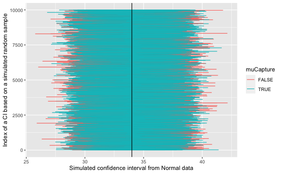

```r
sim_results_df %>%
  ggplot() +
  geom_segment(aes(    x = lower,    y = rowname,
                    xend = upper, yend = rowname,
                   color = muCapture)) +
  geom_vline(aes(xintercept = 34)) +      # mu reference is hard coded here because mu wasn't returned by `ciSim()`
  xlab("Simulated confidence interval from Normal data") +
  ylab("Index of a CI based on a simulated random sample")
```

```r
# how often did our 95% CI actually capture mu? Easy!

mean(sim_results_df$muCapture)
```

```
[1] 0.9485
```